# RSQSim Runs

NOTE: Results table (at end of document) is latex/pdf specific and does not work in html.

# Run 1

- Main fault
  - 5 km $x$ 3 km
  - vertical
  - strike-slip
  - 100 m elements
  - top edge at 2 km depth
  - initial normal stress: 100 MPa
  - initial shear stress: 65 MPa
- Random faults
  - n = 2000
  - size: to produce GR between M=0 and M=2
  - orientation: parallel to main fault
  - position: exponentially distributed distance from random main fault element, random direction
  - eliminate those within 10 m of main fault
  - initial stresses: same as main fault
- Injection
  - `makeInjectionHistory()`’s default values:
    - diffusivity, $\kappa = 0.008 \mathrm{m}^2/\mathrm{s}$
    - porosity, $\phi = 0.05$
    - compressibility, $c = 5 \cdot 10^{-10} \mathrm{Pa}^{-1}$
    - injection rate, $Q = 0.0069 \mathrm{m}^3/\mathrm{s}$
  - 500 m from center point of main fault

# Run 2

Same as Run1 except for:

- Random faults
  - orientation: perturbed from that of main fault with a standard deviation of 10$^\circ$ about uniformly distributed random axes

# Run 3

Same as Run 2 except:

- Main fault
  - initial shear stress: 63 MPa
- Random faults
  - initial shear stress: 63 $\pm$ 1 MPa (mean $\pm$ standard deviation)

# Run 4

Same as Run 3 except:

- Main fault
  - initial shear stress: 62 MPa

# Run 5

Same as Run 4 except:

- Main fault
  - initial shear stress: 62.8 MPa

# Run 6

Same as Run 5 except:

- Main fault
  - initial shear stress: 63.2 MPa

# Run 7

Same as Run 6 except:

- Random faults
  - initial shear stress: 65 $\pm$ 1 MPa

# Run 8

Same as Run 7 except:

- Random faults
  - initial shear stress: 66 $\pm$ 1 MPa

# Run 100

Same as Run 6 except:

- Random faults
  - n = 5000

# Run 101

Same as Run 100 except:

- Random faults
  - n = 10000

# Run 102

Same as Run 101 except:

- Injection
  - 1500 m from center of fault

# Run 103

Same as Run 102 except:

- Injection
  - 1000 m from center of fault

# Run 104

Same as Run 103 except:

- Main fault
  - initial shear stress: 66.7 MPa

# Results table

If you take the $f_{as}$-naive as being the true answer, and if you count the cases where $f_{as}$-naive is 0.00 and the lower end of the 68% CIs for Bayesian fitting of *Saichev and Sornette* [2007] is 0.01 or 0.02 as being close enough, then the true answer falls within the 68% CIs 9 out of 13 times, so 69% of the time (when the late outliers are removed).

The *Hainzl et al.* [2006] method seriously overestimates the aftershock fraction in most cases.

The *Zaliapin and Ben-Zion* [2016] method works quite well (or agrees with the naive counting anyway) though it does have issues when there are zero aftershocks.

# Scatter plots of various aftershock fractions

The SS2007 and H2006 estimates are those with very late events removed. The SS2007 and Zaliapin estimates also have their 68% CIs plotted. The Zaliapin CIs are the central estimate $\pm$ the standard error estimated by `fitdistr()` for the weight of the gaussian with the smaller mean.

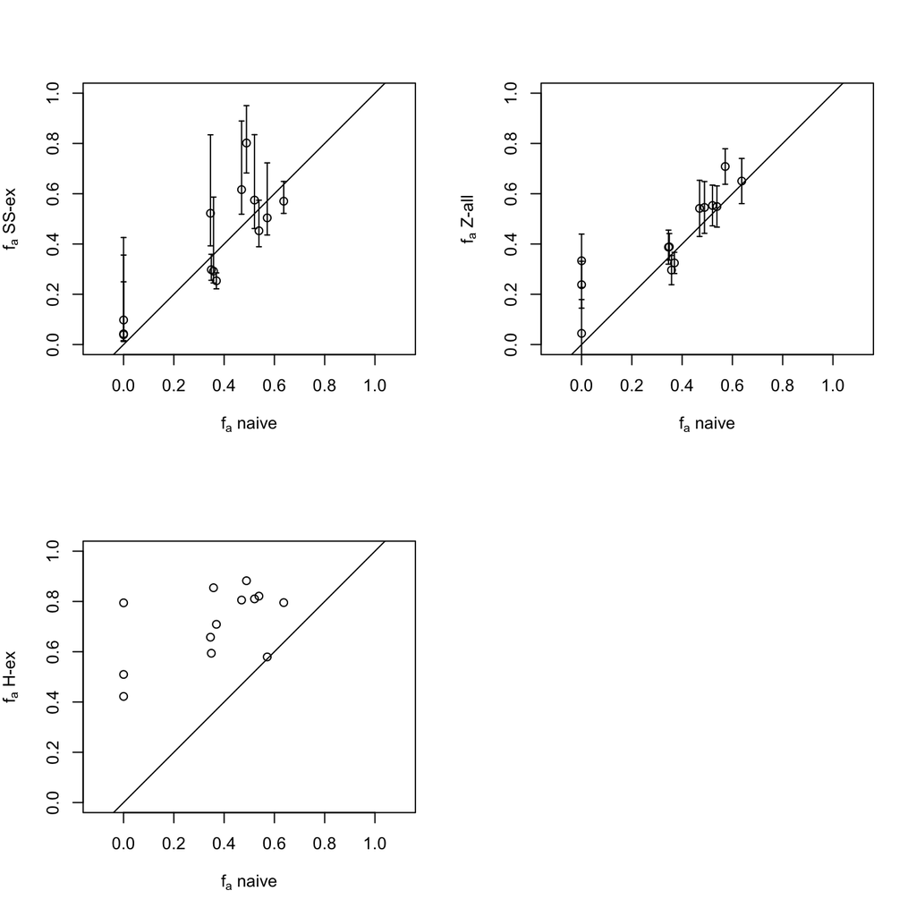

```r
par(mfrow=c(2,2))

plot(results$af.naive, results$af.ss2007.excludelate, xlim=c(0,1), ylim=c(0,1), asp=1,
     xlab=expression(paste(f[a], " naive")), ylab=expression(paste(f[a], " SS-ex")))
arrows(results$af.naive, results$af.ss2007.excludelate.CI0.16,
       results$af.naive, results$af.ss2007.excludelate.CI0.84,
       angle=90, code=3, length=0.02)
abline(0,1)

plot(results$af.naive, results$af.z, xlim=c(0,1), ylim=c(0,1), asp=1,
     xlab=expression(paste(f[a], " naive")), ylab=expression(paste(f[a], " Z-all")))
arrows(results$af.naive, results$af.z - results$af.z.alpha.se,
       results$af.naive, results$af.z + results$af.z.alpha.se,
       angle=90, code=3, length=0.02)
abline(0,1)

plot(results$af.naive, results$af.h2006.excludelate, xlim=c(0,1), ylim=c(0,1), asp=1,
     xlab=expression(paste(f[a], " naive")), ylab=expression(paste(f[a], " H-ex")))
abline(0,1)
```

## Two different aftershock fraction from *Zaliapin and Ben-Zion* [2016]

They fit a two gaussian mixture distribution to the distances, then find the distance at which the two component gaussians are equal, and count all events with distances to their parent less than this distance as aftershocks. This makes sense if you want to divide the seismicity into clusters/sequences. But if you just want the aftershock fraction, you could just use the weight of the gaussian with the smaller mean? Below is a scatter plot of these two alternatives.

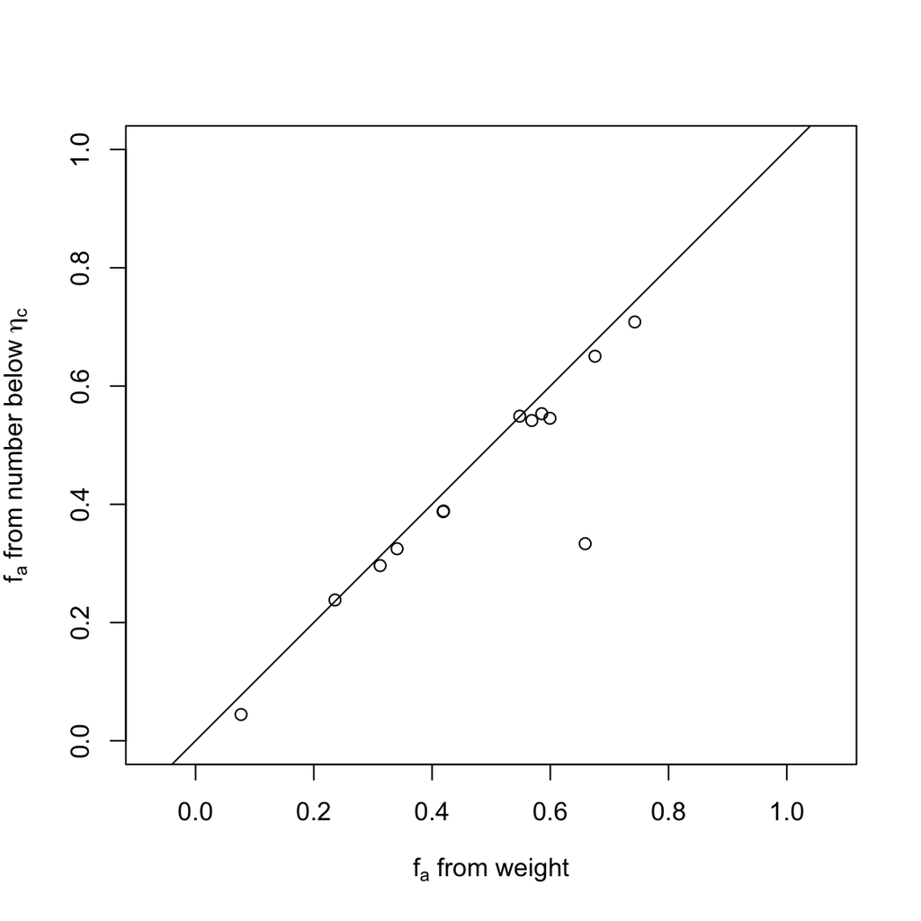

```r
plot(results$af.z.alpha, results$af.z, asp=1, xlim=c(0,1), ylim=c(0,1),
     xlab=expression(paste(f[a], " from weight")),
     ylab=expression(paste(f[a], " from number below ", eta[c])))
abline(0,1)
```

These mostly agree pretty closely. The only exception is Run102 which is one of the runs with zero aftershocks, so the fitting of two gaussians to the Zaliapin distance isn’t meaningful.

# References

Hainzl, S., F. Scherbaum, and C. Beauval (2006), Estimating background activity based on interevent-time distribution, *Bulletin of the Seismological Society of America*, *96*(1), 313–320.

Saichev, A., and D. Sornette (2007), Theory of earthquake recurrence times, *Journal of Geophysical Research: Solid Earth*, *112*(B4).

Zaliapin, I., and Y. Ben-Zion (2016), Discriminating characteristics of tectonic and human-induced seismicity, *Bulletin of the Seismological Society of America*, *106*(3), 846–859.